# w2w

(la couche d’accès à la base de données)

# Design Pattern DAO

# Définition

DAO : classe responsable des opération de CRUD pour une entité.

Entité : Business Object / objet métier / objet “modèle”… un objet à persister correspondant à l’un des élements de données propre à une application.

### Définition tirée d’un livre de référence :

« The DAO design pattern originated in Sun’s Java Blueprints. [..] A DAO defines an interface to persistence operations (CRUD and finder methods) relating to a particular persistence entity ; it advises you to group together code that relates to persistence of that entity. »

(Bauer C. & King G., Java Persistence with Hibernate, Manning, 2007, p. 709.)

### Documentation officielle d’Oracle :

https://www.oracle.com/technetwork/java/dataaccessobject-138824.html

# Utilisation (CRUD)

Create :

```
UserDAO $userDAO = new UserDAO();
$user = new User("Roger", "Dupont");
$userDAO->save($user); # ou insert(), ou add(), etc.
```

Read :

```
$user = $userDAO->findById(12); # ou find(), ou selectById(), etc.
$user = $userDAO->findByEmail("roger.dupont@hotmail.com");
$users = $userDAO->findAll();
...
```

Update :

```
$user = $userDAO->findById(12);
$user->setFirstName("Rogère");
$userDAO->update($user);
```

Delete :

```
$user = $userDAO->findById(12);
$userDAO->delete($user);
```

# Implémentation PHP en PDO

https://www.php.net/manual/fr/intro.pdo.php (équivalent JDBC en Java)

```
class UserDAO extends BaseDAO
{

    const SQL_SELECT = "SELECT us.id, user_name, email, email_verified, password_hash, first_name, last_name, created_at, updated_at, last_login_at, banned, number_reviews, ro.id AS role_id, ro.name AS role_name, ro.description as role_description FROM users AS us
        INNER JOIN roles AS ro ON us.fk_role_id=ro.id";

    public function fetchFromRow($row)
    {
        $item = new $this->className();
        if (isset($row["id"])) {
            $item->setId($row["id"]);
        }
        if (isset($row["user_name"])) {
            $item->setUserName($row["user_name"]);
        }
        # ..etc.
    }

    public function selectByEmail($email)
    {
        if ($pdo = $this->getPDO()) {
            $sql = self::SQL_SELECT . " WHERE email=:email";
            if ($stmt = $pdo->prepare($sql)) {
                $stmt->bindValue(":email", $email);
                if ($stmt->execute()) {
                    if ($row = $stmt->fetch()) {
                        if ($item = $this->fetchFromRow($row)) {
                            return $item;
                        }
                    }
                }
                $stmt->closeCursor();
            }
        }
    }

    # ..

}
```

```
class UserDAO extends BaseDAO
{

    public function insert(User $user)
    {
        if ($pdo = $this->getPDO()) {
            $sql = "INSERT INTO users (user_name, email, email_verified, password_hash, first_name, last_name, created_at, updated_at, last_login_at, banned, number_reviews, fk_role_id)
                VALUES (:user_name, :email, :email_verified, :password_hash, :first_name, :last_name, :created_at, :updated_at, :last_login_at, :banned, :number_reviews, :fk_role_id)";
            if ($stmt = $pdo->prepare($sql)) {
                $stmt->bindValue(":user_name", $user->getUserName());
                $stmt->bindValue(":email", $user->getEmail());
                $stmt->bindValue(":email_verified", $user->getEmailVerified() ? true : false, \PDO::PARAM_BOOL);
                $stmt->bindValue(":password_hash", $user->getPasswordHash());
                $stmt->bindValue(":first_name", $user->getFirstName());
                $stmt->bindValue(":last_name", $user->getLastName());
                $this->bindTimestampToDatetime($stmt, ":created_at", $user->getCreatedAt());
                $this->bindTimestampToDatetime($stmt, ":updated_at", $user->getUpdatedAt());
                $this->bindTimestampToDatetime($stmt, ":last_login_at", $user->getLastLoginAt());
                $stmt->bindValue(":banned", $user->isBanned() ? true : false, \PDO::PARAM_BOOL);
                $stmt->bindValue(":number_reviews", $user->getNumberReviews());
                if ($role = $user->getRole()) {
                    $roleId = $role->getId();
                } else {
                    $roleId = null;
                }
                $stmt->bindValue(":fk_role_id", $roleId);
                $rs = $stmt->execute();
                $id = $pdo->lastInsertId();
                if ($id > 0) {
                    $user->setId($id);
                    return $id;
                }
            }
        }
        return false;
    }

}
```

- très répétitif
- très laborieux à modifier dès qu’on veut apporter une modification à l’entité ou à la db
- vite complexe si on décide d’abstraire soi-même le code pour éviter cette répétition

# Doctrine

# ORM PHP de référence

ORM : Object Relational Mapping, outil qui automatise la conversion entre le modèle objet d’une application et le modèle relationnel d’un SGBDR.

https://en.wikipedia.org/wiki/Object-relational_mapping

Le principe de base d’un ORM comme Doctrine :

1. on définit le “mapping” propre à nos entités, c’est-à-dire la façon dont elles doivent êtres persistées en BDD, et les relations existant entre elles.
2. on utilise ensuite l’API de l’ORM pour effectuer les différentes opérations de persistence (CRUD + recherches) sur les entitées.

Doctrine est utilisé par Symfony, framework MVC (Model-View-Controller) très populaire, pour sa partie Model.

https://www.doctrine-project.org/projects/doctrine-orm/en/current/tutorials/getting-started.html

# Mapping Doctrine

En général, avec un système d’annotations présentes dans des blocs de commentaires dans la classe entité (parce que pas d’annotations natives en PHP).

(Peut aussi se faire dans des fichiers de configuration XML.)

### classe User

(Allégée pour l’exemple)

```
use \Doctrine\Common\Collections\ArrayCollection;

/**
 * @Entity
 * @Table(name="users")
 */
class User
{

    /**
     * @Id
     * @Column(type="integer")
     * @GeneratedValue
     */
    private $id;

    /**
     * @Column(name="user_name")
     */
    private $userName;

    /**
     * @Column
     */
    private $email;

    /**
     * @Column(name="email_verified", type="boolean")
     */
    private $emailVerified;

    /**
     * @Column(name="last_login_at", type="datetime")
     */
    private $lastLoginAt;

    /**
     * @ManyToOne(targetEntity=\w2w\Model\Role::class)
     * @JoinColumn(name="fk_role_id", referencedColumnName="id")
     */
    private $role;

    /**
     * @OneToMany(targetEntity="\w2w\Model\Review", mappedBy="user")
     */
    protected $reviews = [];

    public function __construct()
    {
        $this->reviews = new ArrayCollection();
    }

}
```

### classe Role

```
/**
 * @Entity
 * @Table(name="roles")
 */
class Role
{

    # ..

    /**
     * Cette clé primaire n'est pas auto-incrémentée !
     * @Id
     * @Column(type="integer")
     */
    private $id;

    /**
     * @Column
     */
    private $name;

    /**
     * @Column
     */
    private $description;

    # ..
}
```

### classe Review

Côté “many” d’une relation “ManyToOne”.

La variable membre **user** de la classe **Review** correspond à l’attribut **mappedBy** dans la classe **User**.

```
/**
 * @Entity
 * @table(name="reviews")
 */
class Review
{

    # ..

    /**
     * @ManyToOne(targetEntity=\w2w\Model\User::class)
     * @JoinColumn(name="fk_user_id", referencedColumnName="id")
     */
    private $user;

    # ..

}
```

# API Doctrine

### EntityManager

https://www.doctrine-project.org/projects/doctrine-orm/en/current/tutorials/getting-started.html :

« Doctrine’s public interface is through the EntityManager. This class provides access points to the complete lifecycle management for your entities, and transforms entities from and back to persistence. »

https://www.doctrine-project.org/projects/doctrine-orm/en/current/reference/configuration.html :

```
use Doctrine\ORM\Tools\Setup;
use Doctrine\ORM\EntityManager;

$paths = array("/path/to/entity-files");
$isDevMode = false;

// the connection configuration
$dbParams = array(
    'driver'   => 'pdo_mysql',
    'user'     => 'root',
    'password' => '',
    'dbname'   => 'foo',
);

$config = Setup::createAnnotationMetadataConfiguration($paths, $isDevMode);
$entityManager = EntityManager::create($dbParams, $config);
```

### Create

La classe Product étant déclarée comme une entité (@Entity…) :

```
$product = new Product();
$product->setName($newProductName);
$entityManager->persist($product);
$entityManager->flush();
```

https://www.doctrine-project.org/projects/doctrine-orm/en/current/tutorials/getting-started.html :

« This distinction between persist and flush is what allows the aggregation of all database writes (INSERT, UPDATE, DELETE) into one single transaction, which is executed when flush() is called. Using this approach, the write-performance is significantly better than in a scenario in which writes are performed on each entity in isolation. »

### Read

```
$product = $entityManager->find('Product', $id);
```

```
$productRepository = $entityManager->getRepository('Product');
$products = $productRepository->findAll();
```

https://www.doctrine-project.org/projects/doctrine-orm/en/current/tutorials/getting-started.html :

« The EntityManager#getRepository() method can create a finder object (called a repository) for every type of entity. It is provided by Doctrine and contains some finder methods like findAll(). »

### Update

```
$product = $entityManager->find('Product', $id);
$product->setName($newName);
$entityManager->flush();
```

https://www.doctrine-project.org/projects/doctrine-orm/en/current/tutorials/getting-started.html :

« Doctrine keeps track of all the entities that were retrieved from the Entity Manager, and can detect when any of those entities’ properties have been modified »

### Delete

```
$entityManager->remove($product);
$entityManager->flush();
```

# DAO + ORM

# Classe de base généraliste

Fournit d’avance toutes les opératons de CRUD pour une entité.

```
class DoctrineGenericDAO implements GenericDAO
{

    protected static $entityManager;
    protected $entityClassName; # fully qualified name of mapped entity

    public function __construct($entityClassName)
    {
        $this->entityClassName = $entityClassName;
    }

    public function getEntityManager()
    {
        if (self::$entityManager == null) {
            self::$entityManager = $this->createEntityManager();
        }
        return self::$entityManager;
    }

    public function createEntityManager()
    {
        # ..
    }

    public function find($key)
    {
        if ($em = $this->getEntityManager()) {
            return $em->find($this->entityClassName, $key);
        }
    }

    public function findAll()
    {
        if ($em = $this->getEntityManager()) {
            if ($repo = $em->getRepository($this->entityClassName)) {
                return $repo->findAll();
            }
        }
    }

    public function save($object)
    {
        if ($em = $this->getEntityManager()) {
            $em->persist($object);
            $em->flush();
        }
    }

    public function update($object)
    {
        if ($em = $this->getEntityManager()) {
            $em->flush();
        }
    }

    public function delete($object)
    {
        if ($em = $this->getEntityManager()) {
            if (! is_object($object)) {
                $object = $em->find($this->entityClassName, $object);
            }
            if (is_object($object)) {
                $em->remove($object);
                $em->flush();
            }
        }
    }

    # ..
}
```

# Classe dérivée

N’a plus qu’à implémenter les éventuelles méthodes supplémentaires nécessaires pour l’entitée ciblée.

```
class DoctrineUserDAO extends DoctrineGenericDAO implements UserDAO
{

    public function __construct()
    {
        parent::__construct(User::class);
    }

    public function findByEmail(string $email): ?User
    {
        return $this->findOneBy("email", $email);
    }

    public function findByUserName(string $userName): ?User
    {
        return $this->findOneBy("userName", $userName);
    }

    public function findByRole(Role $role): array
    {
        $dql = sprintf("SELECT u FROM %s u JOIN u.role r WHERE r.id=:id ORDER BY u.userName", User::class);
        $query = $this->getEntityManager()->createQuery($dql)->setParameter("id", $role->getId());
        return $query->getResult();
    }

}
```

```
class DoctrineTagDAO extends DoctrineGenericDAO implements TagDAO
{

    public function __construct()
    {
        parent::__construct(Tag::class);
    }

}
```

# Design Pattern «Abstract Factory»

# Principe

- le code contenait déjà un ensemble de DAO basés sur PDO
- on ajoute un ensemble de DAO basés sur Doctrine portant sur les mêmes entités
- deux implémentations différentes pour offrir les mêmes fonctionnalités

=> cas typique où employer le design pattern Abstract Factory

https://www.oracle.com/technetwork/java/dataaccessobject-138824.html

https://refactoring.guru/design-patterns/abstract-factory

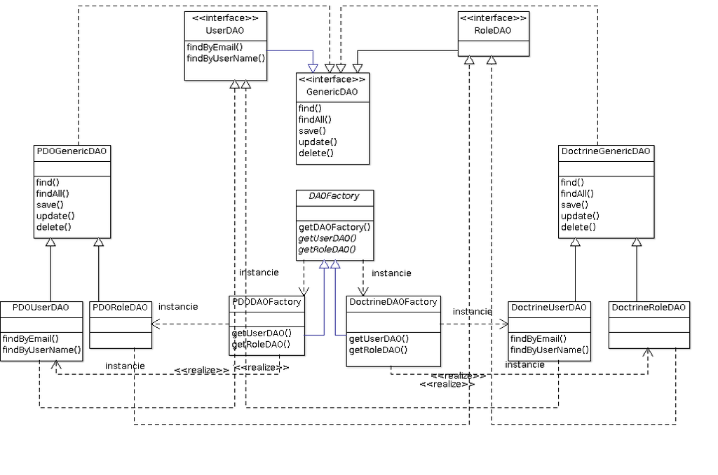

# Utilisation

Dans la plupart des cas, on demandera une implémentation par défaut du DAOFactory, dont le choix peut être paramétré dans un fichier de configuration :

```
$daoFactory = DAOFActory::getDAOFactory(); // -> implémentation par défaut
$userDAO = $daoFactory->getUserDAO(); // ?
$roleDAO = $daoFactory->getRoleDAO(); // ?
```

Mais on peut demander une implémentation spécifique :

```
$daoFactory = DAOFActory::getDAOFactory(DAOFactory::DOCTRINE); // -> DoctrineDAOFactory
$userDAO = $daoFactory->getUserDAO(); // -> DoctrineUserDAO
$roleDAO = $daoFactory->getRoleDAO(); // -> DoctrineRoleDAO
```

```
$daoFactory = DAOFActory::getDAOFactory(DAOFactory::PDO); // -> PDODAOFactory
$userDAO = $daoFactory->getUserDAO(); // -> PDOUserDAO
$roleDAO = $daoFactory->getRoleDAO(); // -> PDORoleDAO
```

# Couplage faible

Vue du reste de l’application, la classe **DAOFactory** constitue la principale interface avec laquelle on interagit, ce qui engendre un couplage faible entre les différentes parties de l’application.

```
$userDAO = new \w2w\DAO\Doctrine\DoctrineUserDAO();
...
```

On peut aussi décider de tester un autre système de persistance (autre ORM, ou solution autre qu’un SGBDR) sans avoir à bouleverser l’application.